# Correlation between Gratitude and Stress

First we collected the data by sending typeforms to different people and IRCs. We got 300 responses in 2 months so we stopped collecting further and focused on doing the analysis work. We have to 2 standardised questionnaires for our analysis : Percieved Stress Scale(for stress analysis) and GQ-6(for gratitude). We jumbled the questions from these 2 questionnaires and did the data collection.

```python
from pyexcel_xlsx import get_data
import json

# Reading the excel of the responses we got
data = get_data("Final Responses.xlsx")
data
```

[output not shown]

[output cut: 302 more lines]

```python
# Know the keys and length of data
data.keys()

len(data[u'Sheet1'])
```

```
301
```

```python
# Get data into processable format

import pandas as pd

df = pd.DataFrame(data[u'Sheet1'])

df.columns = df.iloc[0]
df.reindex(df.index.drop(0))
df.drop(0, inplace = True)

# Print first 5 values of the data table
df.head()
```

|  | Q1 | Q2 | Q3 | Q4 | Q5 | Q6 | Q7 | Q8 | Q9 | Q10 | Q11 | Q12 | Q13 | Q14 | Q15 | Q16 |
| --- | --- | --- | --- | --- | --- | --- | --- | --- | --- | --- | --- | --- | --- | --- | --- | --- |
| 1 | 4 | 3 | 2 | 3 | 2 | 4 | 1 | 2 | 3 | 2 | 4 | 3 | 4 | 4 | 3 | 3 |
| 2 | 2 | 1 | 2 | 1 | 1 | 3 | 2 | 3 | 2 | 5 | 1 | 3 | 1 | 4 | 3 | 3 |
| 3 | 2 | 3 | 4 | 1 | 3 | 2 | 5 | 4 | 4 | 3 | 3 | 1 | 4 | 2 | 4 | 2 |
| 4 | 2 | 3 | 2 | 2 | 3 | 4 | 3 | 3 | 1 | 2 | 3 | 3 | 3 | 4 | 2 | 3 |
| 5 | 2 | 2 | 3 | 1 | 1 | 3 | 4 | 3 | 2 | 3 | 3 | 2 | 2 | 2 | 4 | 1 |

```python
# Convert scoring measures of PSS

df['Q2'].replace([1,2,3,4,5], [0,1,2,3,4], inplace=True)
df['Q3'].replace([1,2,3,4,5], [0,1,2,3,4], inplace=True)
df['Q5'].replace([1,2,3,4,5], [0,1,2,3,4], inplace=True)
df['Q6'].replace([1,2,3,4,5], [0,1,2,3,4], inplace=True)
df['Q7'].replace([1,2,3,4,5], [0,1,2,3,4], inplace=True)
df['Q9'].replace([1,2,3,4,5], [0,1,2,3,4], inplace=True)
df['Q10'].replace([1,2,3,4,5], [0,1,2,3,4], inplace=True)
df['Q12'].replace([1,2,3,4,5], [0,1,2,3,4], inplace=True)
df['Q14'].replace([1,2,3,4,5], [0,1,2,3,4], inplace=True)
df['Q15'].replace([1,2,3,4,5], [0,1,2,3,4], inplace=True)
```

```python
# Convert scoring measures of GQ-6

df['Q1'].replace([1,2,3,4,5], [1,2.5,4,5.5,7], inplace=True)
df['Q4'].replace([1,2,3,4,5], [1,2.5,4,5.5,7], inplace=True)
df['Q8'].replace([1,2,3,4,5], [1,2.5,4,5.5,7], inplace=True)
df['Q11'].replace([1,2,3,4,5], [1,2.5,4,5.5,7], inplace=True)
df['Q13'].replace([1,2,3,4,5], [1,2.5,4,5.5,7], inplace=True)
df['Q16'].replace([1,2,3,4,5], [1,2.5,4,5.5,7], inplace=True)

# Printing first 5 rows of transformed table
df.head()
```

|  | Q1 | Q2 | Q3 | Q4 | Q5 | Q6 | Q7 | Q8 | Q9 | Q10 | Q11 | Q12 | Q13 | Q14 | Q15 | Q16 |
| --- | --- | --- | --- | --- | --- | --- | --- | --- | --- | --- | --- | --- | --- | --- | --- | --- |
| 1 | 5.5 | 2 | 1 | 5.5 | 1 | 3 | 0 | 2.5 | 2 | 1 | 5.5 | 2 | 5.5 | 3 | 2 | 5.5 |
| 2 | 2.5 | 0 | 1 | 1.0 | 0 | 2 | 1 | 5.5 | 1 | 4 | 1.0 | 2 | 1.0 | 3 | 2 | 5.5 |
| 3 | 2.5 | 2 | 3 | 1.0 | 2 | 1 | 4 | 5.5 | 3 | 2 | 5.5 | 0 | 5.5 | 1 | 3 | 2.5 |
| 4 | 2.5 | 2 | 1 | 2.5 | 2 | 3 | 2 | 5.5 | 0 | 1 | 5.5 | 2 | 5.5 | 3 | 1 | 5.5 |
| 5 | 2.5 | 1 | 2 | 1.0 | 0 | 2 | 3 | 5.5 | 1 | 2 | 5.5 | 1 | 2.5 | 1 | 3 | 1.0 |

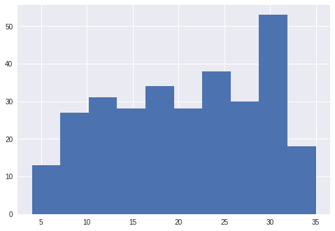

|  | Q1 | Q2 | Q3 | Q4 | Q5 | Q6 | Q7 | Q8 | Q9 | Q10 | Q11 | Q12 | Q13 | Q14 | Q15 | Q16 | pss_score |
| --- | --- | --- | --- | --- | --- | --- | --- | --- | --- | --- | --- | --- | --- | --- | --- | --- | --- |
| 1 | 5.5 | 2 | 1 | 5.5 | 1 | 3 | 0 | 2.5 | 2 | 1 | 5.5 | 2 | 5.5 | 3 | 2 | 5.5 | 21 |
| 2 | 2.5 | 0 | 1 | 1.0 | 0 | 2 | 1 | 5.5 | 1 | 4 | 1.0 | 2 | 1.0 | 3 | 2 | 5.5 | 14 |
| 3 | 2.5 | 2 | 3 | 1.0 | 2 | 1 | 4 | 5.5 | 3 | 2 | 5.5 | 0 | 5.5 | 1 | 3 | 2.5 | 23 |
| 4 | 2.5 | 2 | 1 | 2.5 | 2 | 3 | 2 | 5.5 | 0 | 1 | 5.5 | 2 | 5.5 | 3 | 1 | 5.5 | 17 |
| 5 | 2.5 | 1 | 2 | 1.0 | 0 | 2 | 3 | 5.5 | 1 | 2 | 5.5 | 1 | 2.5 | 1 | 3 | 1.0 | 16 |

```python
# Calculate Stress score using Standardised PSS scoring

df['pss_score'] = df['Q2'] + df['Q3'] + df['Q5'] + (4-df['Q6']) + (4-df['Q7']) + df['Q9'] + (4-df['Q12']) + (4-df['Q10']) + df['Q14'] + df['Q15']

import matplotlib.pyplot as plt

# Plotting histogram for PSS score
df['pss_score'].hist()
plt.show()

# Printing first 5 rows of altered table
df.head()
```

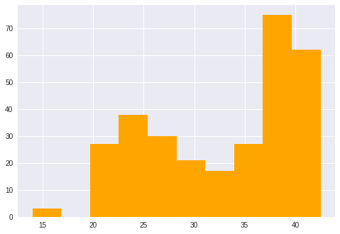

|  | Q1 | Q2 | Q3 | Q4 | Q5 | Q6 | Q7 | Q8 | Q9 | Q10 | Q11 | Q12 | Q13 | Q14 | Q15 | Q16 | pss_score | GQ-6_Score |
| --- | --- | --- | --- | --- | --- | --- | --- | --- | --- | --- | --- | --- | --- | --- | --- | --- | --- | --- |
| 1 | 5.5 | 2 | 1 | 5.5 | 1 | 3 | 0 | 2.5 | 2 | 1 | 5.5 | 2 | 5.5 | 3 | 2 | 5.5 | 21 | 38.0 |
| 2 | 2.5 | 0 | 1 | 1.0 | 0 | 2 | 1 | 5.5 | 1 | 4 | 1.0 | 2 | 1.0 | 3 | 2 | 5.5 | 14 | 21.5 |
| 3 | 2.5 | 2 | 3 | 1.0 | 2 | 1 | 4 | 5.5 | 3 | 2 | 5.5 | 0 | 5.5 | 1 | 3 | 2.5 | 23 | 30.5 |
| 4 | 2.5 | 2 | 1 | 2.5 | 2 | 3 | 2 | 5.5 | 0 | 1 | 5.5 | 2 | 5.5 | 3 | 1 | 5.5 | 17 | 32.0 |
| 5 | 2.5 | 1 | 2 | 1.0 | 0 | 2 | 3 | 5.5 | 1 | 2 | 5.5 | 1 | 2.5 | 1 | 3 | 1.0 | 16 | 27.5 |

```python
# Calculate Gratitude score using Standardised GQ-6 scoring

step1_score = df['Q1'] + df['Q4'] + df['Q8'] + df['Q11'] + df['Q13'] + df['Q16']
df['GQ-6_Score'] = (8-df['Q8']) + (8-df['Q16']) + step1_score
df['GQ-6_Score'].replace([20,21],[14,16], inplace = True)
df['GQ-6_Score'].replace([43,44],[41,42], inplace = True)

# Plotting histogram of GQ-6 score
df['GQ-6_Score'].hist(color='orange')
plt.show()

# Printing first 5 rows of altered table
df.head()
```

```python
# Finding correlation between PSS score and GQ-6 score

correlation_value = df['pss_score'].corr(df['GQ-6_Score'])
print(correlation_value)
```

```
-0.0177466094601
```

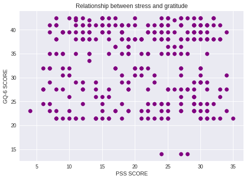

```python
# Plotting between Both scores

X = list(df['pss_score'])
Y = list(df['GQ-6_Score'])

# Giving title to the graph
plt.title("Relationship between stress and gratitude")

# Label the axis
plt.xlabel("PSS SCORE")
plt.ylabel("GQ-6 SCORE")

# Showing the graph
plt.scatter(X, Y , s=60, c='purple')
plt.show()
```

```python
# Getting the statistics of the Scores without the y intercept

import statsmodels.api as sm
import numpy as np

model = sm.OLS(df['GQ-6_Score'], df['pss_score']).fit()
predictions = model.predict(df['pss_score'])

# Printing the statistical summary of the datasets
model.summary()
```

OLS Regression Results

| Dep. Variable: | GQ-6_Score | R-squared: | 0.828 |
| --- | --- | --- | --- |
| Model: | OLS | Adj. R-squared: | 0.828 |
| Method: | Least Squares | F-statistic: | 1442. |
| Date: | Wed, 25 Oct 2017 | Prob (F-statistic): | 2.10e-116 |
| Time: | 12:54:16 | Log-Likelihood: | -1218.7 |
| No. Observations: | 300 | AIC: | 2439. |
| Df Residuals: | 299 | BIC: | 2443. |
| Df Model: | 1 |  |  |
| Covariance Type: | nonrobust |  |  |

|  | coef | std err | t | P>\|t\| | [0.025 | 0.975] |
| --- | --- | --- | --- | --- | --- | --- |
| pss_score | 1.3888 | 0.037 | 37.972 | 0.000 | 1.317 | 1.461 |

| Omnibus: | 14.771 | Durbin-Watson: | 1.625 |
| --- | --- | --- | --- |
| Prob(Omnibus): | 0.001 | Jarque-Bera (JB): | 6.856 |
| Skew: | -0.115 | Prob(JB): | 0.0325 |
| Kurtosis: | 2.296 | Cond. No. | 1.00 |

```python
# Getting the statistics of the Scores with Y intercept

X_stat = df['pss_score']
y_stat = df['GQ-6_Score']

# Intercept added here
X_stat = sm.add_constant(X_stat)

model = sm.OLS(y_stat, X_stat).fit()
predictions = model.predict(X_stat)

# Printting the summary of the datasets with intercept value included
model.summary()
```

OLS Regression Results

| Dep. Variable: | GQ-6_Score | R-squared: | 0.000 |
| --- | --- | --- | --- |
| Model: | OLS | Adj. R-squared: | -0.003 |
| Method: | Least Squares | F-statistic: | 0.09388 |
| Date: | Wed, 25 Oct 2017 | Prob (F-statistic): | 0.760 |
| Time: | 12:54:20 | Log-Likelihood: | -1027.0 |
| No. Observations: | 300 | AIC: | 2058. |
| Df Residuals: | 298 | BIC: | 2065. |
| Df Model: | 1 |  |  |
| Covariance Type: | nonrobust |  |  |

|  | coef | std err | t | P>\|t\| | [0.025 | 0.975] |
| --- | --- | --- | --- | --- | --- | --- |
| const | 33.4496 | 1.204 | 27.779 | 0.000 | 31.080 | 35.819 |
| pss_score | -0.0166 | 0.054 | -0.306 | 0.760 | -0.123 | 0.090 |

| Omnibus: | 148.673 | Durbin-Watson: | 1.769 |
| --- | --- | --- | --- |
| Prob(Omnibus): | 0.000 | Jarque-Bera (JB): | 26.066 |
| Skew: | -0.419 | Prob(JB): | 2.19e-06 |
| Kurtosis: | 1.824 | Cond. No. | 62.4 |

```python
# Applying Linear Regression Model

from sklearn import linear_model

# Giving input features to the regression model
X_reg = df[['Q1','Q4','Q8','Q11','Q13','Q16','GQ-6_Score']]

# Output feature of the regression model
y_reg = df['pss_score']

# Applying linear regression model to our dataset
lm = linear_model.LinearRegression()
reg_model = lm.fit(X_reg, y_reg)

# Predicting the output feature through the learned model
predictions = lm.predict(X_reg)

# Getting the score of how well the model performed
lm.score(X_reg, y_reg)
```

```
0.011810040006935751
```

```python
# Value of intercept
lm.intercept_
```

```
32.740327421223114
```

```python
# Value of coefficient
lm.coef_
```

```
array([ 0.54235136,  1.06185671, -0.21344392,  0.23505673,  0.80704811,
        0.18792216, -0.7043742 ])
```

# CONCLUSION

Statistical values also shows that people who contributed in our datasets have a lot of stress even after being grateful, which somewhat disagrees with previous studies.

Reason behind this finding maybe hectic schedule of each person, being too busy with their work and not spending a lot of time in social interaction. There maybe some other reasons too behind this which is beyond this study that we have done.

Then we tried to aply linear regression model to our dataset so that we could predict how stressfull a person is with a given gratitude value but seeing the graph and analysis the accuracy is very less as the data is very scattered and doesn't fit along a straight line.

In future, maybe we can try to fit our datasets in different machine learning model and see if the perform well, as SVM and Isolation forest algorithms may work well with our dataset and and predict the results in a better way.